# Figure 5 - IP-MS

Charlotte Soneson, Michael Stadler, Merle Skribbe

2024-08-05

# Parameter values

```r
params
```

```
## $rds150
## [1] "data/ipms_150_sce.rds"
##
## $rds500
## [1] "data/ipms_500_sce.rds"
##
## $rdsdal2
## [1] "data/ipms_dal2_sce.rds"
##
## $complexes
## [1] "data/complexes.json"
##
## $baitclass
## [1] "data/ipms_bait_class.txt"
##
## $dnabinders
## [1] "data/Gene_list_DNAbinders_proteincoding.txt"
##
## $rnabinders
## [1] "data/Gene_list_RNAbinders_proteincoding.txt"
##
## $dbdtxt
## [1] "data/TF_DBD_annotation.txt"
##
## $idmap
## [1] "data/id_mapping_table.txt"
```

# Load required packages and helper functions

```r
suppressPackageStartupMessages({
    library(SingleCellExperiment)
    library(ggplot2)
    library(cowplot)
    library(einprot)
    library(dplyr)
    library(forcats)
    library(jsonlite)
    library(ComplexHeatmap)
    library(colorspace)
    library(ggrepel)
    library(DT)
    library(stringr)
    library(tidyr)
    library(kableExtra)
    library(patchwork)
})

## Source scripts with required helper functions and settings
source("params/plot_settings.R")
source("params/get_testres_function.R")
source("params/ipms_params.R")
source("params/mapping_functions.R")
source("params/ipms_heatmap_functions.R")

## Heatmap sizes
w_ipmsHm <-  84 # heatmap body width (mm)
h_ipmsHm <- 178 # total heatmap height (mm)

fs <- 8  # small font size
fl <- 10 # large font size
ft <- 12 # title font size
```

# Helper functions

```r
## Overwrite the get_legend function from cowplot temporarily,
## since the cowplot one doesn't work with ggplot2 3.5.0
## see https://github.com/wilkelab/cowplot/issues/202

get_legend <- function(plot, legend = NULL) {
    gt <- ggplotGrob(plot)

    pattern <- "guide-box"
    if (!is.null(legend)) {
        pattern <- paste0(pattern, "-", legend)
    }

    indices <- grep(pattern, gt$layout$name)

    not_empty <- !vapply(
        gt$grobs[indices],
        inherits, what = "zeroGrob",
        FUN.VALUE = logical(1)
    )
    indices <- indices[not_empty]

    if (length(indices) > 0) {
        return(gt$grobs[[indices[1]]])
    }
    return(NULL)
}
```

```r
makePie <- function(baitdata, title) {
    ## Expected fraction of 'same family' pairs
    famtbl <- table(baitdata$nbrIntMat |>
                        filter(dbdfam != "Other" &
                                   bait != "Untagged") |>
                        pull(dbdfam))
    nbait <- sum(baitdata$nbrIntMat$bait != "Untagged")
    exp_same <- sum(famtbl * (famtbl - 1)) / (nbait * (nbait - 1))
    print(paste0("Expected fraction of 'same family' pairs: ",
                 round(exp_same, digits = 5)))

    ## Pie chart, within-vs-between DBD family interactions
    pie_data <- baitdata$nbrIntMat |>
        filter(bait != "Untagged") |>
        select(nbrTFs_samefam, nbrTFs_difffam) |>
        pivot_longer(everything(), names_to = "class", values_to = "nbrTF") |>
        group_by(class) |>
        summarize(nbrTF = sum(nbrTF), .groups = "drop") |>
        mutate(ypos = sum(nbrTF) - cumsum(nbrTF) + 0.5 * nbrTF)

    ggplot(
        pie_data,
        aes(x = "", y = nbrTF, fill = class)) +
        geom_col(width = 1) +
        geom_segment(x = 1.55, xend = 1.55,
                     y = 0, yend = exp_same * sum(pie_data$nbrTF),
                     linewidth = 1.5) +
        geom_text(aes(y = ypos, label = nbrTF), size = 7, color = "black") +
        coord_polar("y", start = 0) +
        scale_fill_manual(values = c(nbrTFs_samefam = main_colors[3],
                                     nbrTFs_difffam = main_colors[5]),
                          labels = c(nbrTFs_samefam = "Same DBD family",
                                     nbrTFs_difffam = "Different DBD family"),
                          name = "") +
        labs(title = title) +
        theme_void()
}
```

# Read data

We load two `SingleCellExperiment` objects, containing data and results from the low- and high-salt experiments, respectively, as well as one object with results from a separate run of Dal2.

```r
sce150 <- readRDS(params$rds150)
sce500 <- readRDS(params$rds500)
scedal2 <- readRDS(params$rdsdal2)
```

We then extract the full list of baits, as well as a classification according to the experiment(s) where a certain bait was pulled down.

```r
idmap <- read.delim(params$idmap)
baitclass <- read.delim(params$baitclass)
DT::datatable(baitclass, rownames = FALSE)
```

| Gene_name | class | class500 |
| --- | --- | --- |
| Ace2 | 150and500 | Lost in 500 mM |
| Cdc10 | 150and500 | Retained in 500 mM |
| Cha4 | nobait |  |
| Cuf1 | 150only |  |
| Cuf2 | nobait |  |
| Deb1 | 150and500 | Lost in 500 mM |
| Esc1 | 150only |  |
| Fep1 | 150only |  |
| Fhl1 | 150only |  |
| Fil1 | 150only |  |

[output cut: 80 more lines]

In the following set of IPs, we identified the bait as not pulled down.

```r
(nobait_150 <- baitclass$Gene_name[baitclass$class == "nobait"])
```

```
## [1] "Cha4"        "Cuf2"        "Atf21"       "Cbf12"       "Sre2"
## [6] "SPBC1348.12" "Untagged"
```

We also read a list of known complexes, which will be used for annotation purposes.

```r
complexes <- jsonlite::read_json(params$complexes, simplifyVector = TRUE)
complexes$`MBF transcription complex`$color <- main_colors[5]
complexes$`CCAAT-binding factor complex`$color <- main_colors[1]
complexes$`Atf1-Pcr1`$color <- main_colors[3]
names(complexes)
```

```
##  [1] "NuA4"                            "SAGA"
##  [3] "19S proteasome - base"           "Clr6 HDAC - complex I'"
##  [5] "SREBP-SCAP"                      "SPBC16G5.16-SPBC530.08"
##  [7] "Atf1-Pcr1"                       "chaperonin-containing T-complex"
##  [9] "CCAAT-binding factor complex"    "Dal2"
## [11] "Cyc8(Ssn6)-Tup1"                 "Rad24-Rad25"
## [13] "Ste11-Cdc2-Cig2"                 "Pap1-Prr1"
## [15] "MBF transcription complex"
```

Finally we load a table classifying each TF to its DNA-binding domain family.

```r
dbd <- read.delim(params$dbdtxt) |>
    dplyr::mutate(Gene_name = .capitalize(Gene_name))
DT::datatable(dbd, extensions = "FixedColumns", rownames = FALSE,
              filter = list(position = "top", clear = FALSE),
              options = list(scrollX = TRUE,
                             fixedColumns = list(leftColumns = 1),
                             search = list(regex = FALSE, caseInsensitive = TRUE),
                             pageLength = 10))
```

| TFID | PomBaseID | Gene_name | UniprotID | Taxonomic_distribution | DBD_class | DBD_feature | Conserved_human | Predicted_conserved_mouse |
| --- | --- | --- | --- | --- | --- | --- | --- | --- |
| ID1 | SPAC6G10.12c | Ace2 | O14258 | other | COG5048 | Zinc-coordinated | False | False |
| ID2 | SPBC336.12c | Cdc10 | P01129 | fungi only | KilA-N | TF homology | False | False |
| ID3 | SPBC1683.13c | Cha4 | Q9P6I9 | fungi only | Zn(II)2Cys6 | Zinc-coordinated | False | False |
| ID4 | SPAC31A2.11c | Cuf1 | Q09728 | fungi only | Copper-fist | TF homology | False | False |
| ID5 | SPCC584.02 | Cuf2 | O94588 | fungi only | Copper-fist | TF homology | False | False |
| ID6 | SPAC1B1.01 | Deb1 | O13862 | other | zf-C2H2 | Zinc-coordinated | False | False |
| ID7 | SPAC56F8.16 | Esc1 | Q04635 | other | bHLH_SF | Basic helix-loop-helix | False | False |
| ID8 | SPAC23E2.01 | Fep1 | Q10134 | other | ZnF_GATA | Zinc-coordinated | False | True |
| ID9 | SPAC1142.08 | Fhl1 | O14270 | other | COG5025 (FH) | Forkhead | False | False |
| ID10 | SPCC1393.08 | Fil1 | O94720 | other | ZnF_GATA | Zinc-coordinated | False | True |

[output cut: 79 more lines]

# Extract data for heatmaps

```r
hmdata_150 <- makeHeatmapData(sce = sce150, adjpthr = adjpThreshold,
                              log2fcthr = log2fcThreshold, conc = 150)
hmdata_150_loose <- makeHeatmapData(sce = sce150, adjpthr = adjpThresholdLoose,
                                    log2fcthr = log2fcThreshold, conc = 150)
hmdata_500 <- makeHeatmapData(sce = sce500, adjpthr = adjpThreshold,
                              log2fcthr = log2fcThreshold, conc = 500)
hmdata_500_loose <- makeHeatmapData(sce = sce500, adjpthr = adjpThresholdLoose,
                                    log2fcthr = log2fcThreshold, conc = 500)


baitdata_150 <- makeBaitHeatmapData(sce = sce150, adjpthr = adjpThreshold,
                                    log2fcthr = log2fcThreshold,
                                    nbrIntMat = hmdata_150$nbrIntMat)
baitdata_150_loose <- makeBaitHeatmapData(sce = sce150, adjpthr = adjpThresholdLoose,
                                          log2fcthr = log2fcThreshold,
                                          nbrIntMat = hmdata_150_loose$nbrIntMat)
baitdata_500 <- makeBaitHeatmapData(sce = sce500, adjpthr = adjpThreshold,
                                    log2fcthr = log2fcThreshold,
                                    nbrIntMat = hmdata_500$nbrIntMat)
baitdata_500_loose <- makeBaitHeatmapData(sce = sce500, adjpthr = adjpThresholdLoose,
                                          log2fcthr = log2fcThreshold,
                                          nbrIntMat = hmdata_500_loose$nbrIntMat)
```

# Export data for TFexplorer

Here, we export data for use with TFexplorer, for both the low- and high-salt conditions.

```r
## Heatmap data
.prepDataForTFexplorer <- function(sce, outfileHeatmap, outfileVolcano, idmap) {
    ## Heatmap
    ## -------------------------------------------------------------------------
    testres <- .getTestCols(sce = sce)
    testres$tstat <- testres$tstat[, colnames(testres$tstat) !=
                                       "Untagged_150_tube_vs_compl_Untagged_150_tube.t"]
    tstat <- testres$tstat
    colnames(tstat) <- .getProteinNameFromComparison(colnames(tstat))
    TFs <- colnames(tstat)

    ## set NAs to minimum value
    tstat[is.na(tstat)] <- min(na.omit(tstat))
    ## set all values below 0 to 0
    tstat[tstat < 0] = 0

    ## convert it back to a matrix
    heatmap_data_mean <- as.matrix(tstat)

    ## cluster the rows (to avoid slow clustering in LinkedCharts)
    dist_mat1 <- dist(heatmap_data_mean, method = "euclidean")
    hclust_avg1 <- hclust(dist_mat1, method = "average")
    heatmap_data_mean_clustered <- heatmap_data_mean[hclust_avg1$order, ]

    ## calculate row max
    heatmapRowMax <- apply(heatmap_data_mean_clustered, 1, max)

    ## add Pombase IDs and names and uniprot IDs
    PomIds2 <- left_join(data.frame(row.names(heatmap_data_mean_clustered)),
                         idmap |> dplyr::mutate(unique_einprot_id = .capitalize(unique_einprot_id)),
                         by = c("row.names.heatmap_data_mean_clustered." =
                                    "unique_einprot_id"))
    PomIds1 <- ifelse(is.na(PomIds2$gene_stable_id),
                      PomIds2$row.names.heatmap_data_mean_clustered.,
                      PomIds2$gene_stable_id)
    UniprotIDs <- PomIds2$xref

    ## convert the gene names to protein names
    colnames(heatmap_data_mean_clustered) <-
        .capitalize(colnames(heatmap_data_mean_clustered))
    rownames(heatmap_data_mean_clustered) <-
        .capitalize(rownames(heatmap_data_mean_clustered))

    ## save heatmap and related data as JSON
    heatmap_data_mean2 <- toJSON(list(
        heatmapMatrix = heatmap_data_mean_clustered,
        TFs = colnames(heatmap_data_mean_clustered),
        proteins = rownames(heatmap_data_mean_clustered),
        MaxTSTAT = heatmapRowMax,
        PomIds = PomIds1,
        UniprotIDs = UniprotIDs),
        pretty = TRUE)
    write(heatmap_data_mean2, file = outfileHeatmap)

    ## Volcano plots
    ## -------------------------------------------------------------------------
    ## extract comparisons (include only plate format for Atf1 and untagged)
    volcano_list <- metadata(sce)$testres$tests
    volcano_list <- volcano_list[sub("\\.t", "", colnames(testres$tstat))]
    TFIDs <- names(volcano_list)
    TFnames <- .getProteinNameFromComparison(TFIDs)

    ## using sce object
    vp_list <- lapply(
        structure(colnames(heatmap_data_mean_clustered),
                  names = colnames(heatmap_data_mean_clustered)),
        function(selTF) {
            VP <- volcano_list[[which(TFnames == selTF)]][, c("pid", "logFC", "adj.P.Val",
                                                              "mlog10p", "showInVolcano")]
            VP$DE <- ifelse(VP$showInVolcano, "significant", "not significant")

            ## replace NAs with 0
            VP <- replace_na(data = VP,
                             replace = list(pid = "unknown",
                                            logFC = 0,
                                            adj.P.Val = 1,
                                            mlog10p = 0,
                                            DE = "not significant"))

            ## add to list
            VP[, c("pid", "logFC", "adj.P.Val", "mlog10p", "DE")]
        })

    ## convert the gene names to protein names
    for (i in seq_along(vp_list)) {
        rownames(vp_list[[i]]) <- .capitalize(rownames(vp_list[[i]]))
        vp_list[[i]]$pid <- rownames(vp_list[[i]])
    }

    ## save volcano plot data as JSON
    vp_list2 <- toJSON(vp_list, dataframe = "columns", pretty = TRUE)
    write(vp_list2, file = outfileVolcano)
}

.prepDataForTFexplorer(sce = sce150,
                       outfileHeatmap = "data/TSTAT_matrix4heatmap_150mM.json",
                       outfileVolcano = "data/volcanoData_150mM.json",
                       idmap = idmap)
.prepDataForTFexplorer(sce = sce500,
                       outfileHeatmap = "data/TSTAT_matrix4heatmap_500mM.json",
                       outfileVolcano = "data/volcanoData_500mM.json",
                       idmap = idmap)
```

# Facts and figures

## Identification of baits in IP-MS

```r
table(baitclass$class)
```

```
##
## 150and500   150only    nobait
##        40        43         7
```

## Summary tables

```r
makeInteractorSummary <- function(sce, baitdata, adjp_cutoff, logfc_cutoff, idmap,
                                  baits_to_keep, tbl_title) {
    ni_tc <- .getTestCols(sce = sce, adjp_cutoff = adjp_cutoff,
                          logfc_cutoff = logfc_cutoff)
    ni_idx <- .getOrigBaitNameFromComparison(colnames(ni_tc$tstat), idmap = idmap) %in%
        baits_to_keep
    ni_int <- ni_tc$interactor[, ni_idx]
    ni_baits <- cbind(match(.getProteinNameFromComparison(colnames(ni_int)),
                            rownames(ni_int)),
                      seq_len(ncol(ni_int)))
    ni_int[ni_baits] <- NA

    ## TF-TF interactions
    tmp <- baitdata$nbrIntMat |>
        filter(nbrTFs_wobait > 0)

    ## Bilateral TF-TF interactions
    nbr_bilateral <- tmp |>
        select(bait, TFs) |>
        separate_longer_delim(TFs, delim = ",") |>
        mutate(o1 = paste(bait, TFs, sep = "-"),
               o2 = paste(TFs, bait, sep = "-")) |>
        filter(o1 %in% o2) |>
        nrow()

    data.frame(`Total number of TFs for which bait was pulled down` = ncol(ni_int),
               `Total number of interactions (excluding bait itself)` = length(which(ni_int > 0)),
               `Number of TFs with interactions` = length(which(colSums(ni_int, na.rm = TRUE) > 0)),
               `Number of TFs without observed interactions` = length(which(colSums(ni_int, na.rm = TRUE) == 0)),
               `Total number of TF-TF interactions (excluding bait itself)` = sum(baitdata$nbrIntMat$nbrTFs_wobait),
               `Number of TFs involved in these TF-TF interactions` = length(unique(c(tmp$bait, unlist(strsplit(tmp$TFs, ","))))),
               `Number of bilateral TF-TF interaction` = nbr_bilateral,
               check.names = FALSE) |>
        pivot_longer(cols = everything(), names_to = "Aspect", values_to = tbl_title)
}

makeInteractorSummary(sce = sce150, baitdata = baitdata_150, adjp_cutoff = adjpThreshold,
                      logfc_cutoff = log2fcThreshold, idmap = idmap,
                      baits_to_keep = baitclass$Gene_name[baitclass$class != "nobait"],
                      tbl_title = "150 mM, strict cutoff") |>
    dplyr::full_join(
        makeInteractorSummary(sce = sce500, baitdata = baitdata_500, adjp_cutoff = adjpThreshold,
                              logfc_cutoff = log2fcThreshold, idmap = idmap,
                              baits_to_keep = baitclass$Gene_name[baitclass$class != "nobait"],
                              tbl_title = "500 mM, strict cutoff")
    ) |>
    dplyr::full_join(
        makeInteractorSummary(sce = sce150, baitdata = baitdata_150_loose, adjp_cutoff = adjpThresholdLoose,
                              logfc_cutoff = log2fcThreshold, idmap = idmap,
                              baits_to_keep = baitclass$Gene_name[baitclass$class != "nobait"],
                              tbl_title = "150 mM, lenient cutoff")
    ) |>
    dplyr::full_join(
        makeInteractorSummary(sce = sce500, baitdata = baitdata_500_loose, adjp_cutoff = adjpThresholdLoose,
                              logfc_cutoff = log2fcThreshold, idmap = idmap,
                              baits_to_keep = baitclass$Gene_name[baitclass$class != "nobait"],
                              tbl_title = "500 mM, lenient cutoff")
    ) |>
    kbl() |>
    kable_styling()
```

| Aspect | 150 mM, strict cutoff | 500 mM, strict cutoff | 150 mM, lenient cutoff | 500 mM, lenient cutoff |
| --- | --- | --- | --- | --- |
| Total number of TFs for which bait was pulled down | 83 | 40 | 83 | 40 |
| Total number of interactions (excluding bait itself) | 352 | 110 | 881 | 202 |
| Number of TFs with interactions | 43 | 24 | 60 | 29 |
| Number of TFs without observed interactions | 40 | 16 | 23 | 11 |
| Total number of TF-TF interactions (excluding bait itself) | 21 | 15 | 39 | 17 |
| Number of TFs involved in these TF-TF interactions | 17 | 14 | 30 | 14 |
| Number of bilateral TF-TF interaction | 16 | 12 | 18 | 14 |

# Figure 5

## Summary heatmaps using results from the statistical tests (150 mM NaCl)

### Bait-vs-bait heatmap

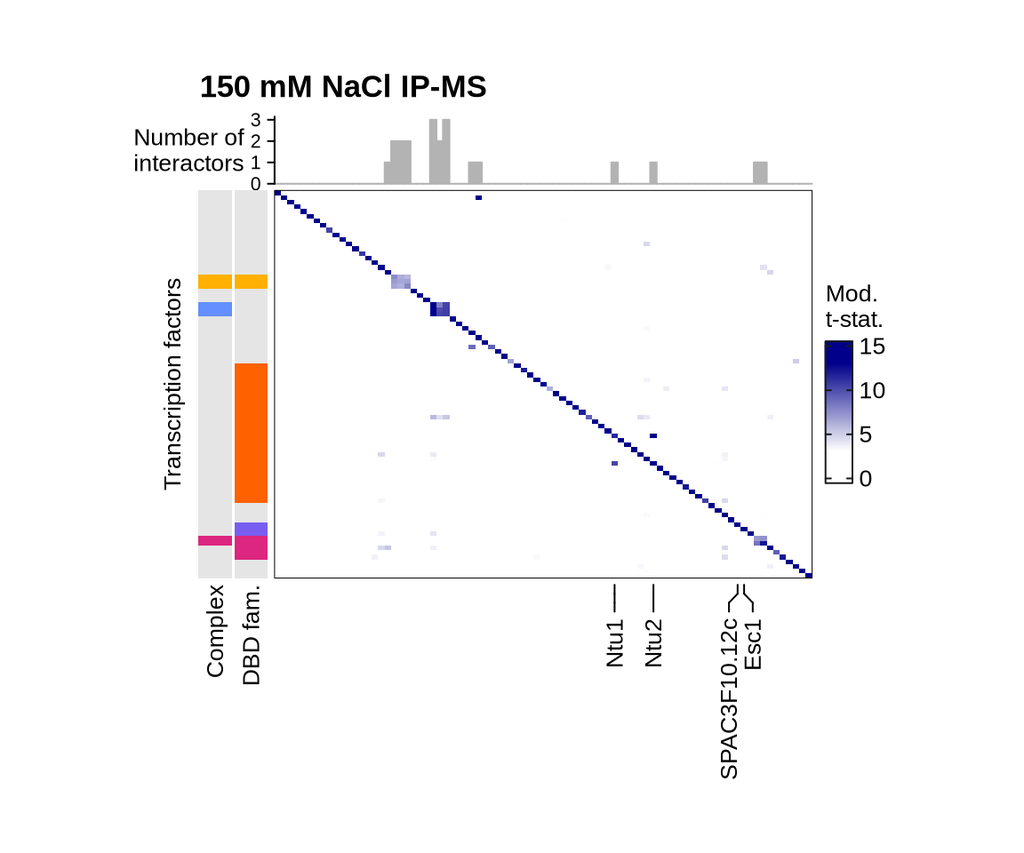

```r
hm1b <- Heatmap(baitdata_150$mat,
                cluster_rows = FALSE,
                cluster_columns = FALSE,
                col = makeHeatmapCol(stringency = "high"),
                border = TRUE,
                border_gp = gpar(lwd = 0.5),
                name = "Mod.\nt-stat.",
                na_col = binary_heatmap_colors["FALSE"],
                column_title = paste(c("150 mM NaCl IP-MS", rep(" ", 45)), collapse = ""),
                row_title = "Transcription factors",
                column_title_gp = gpar(fontsize = fl + 3, fontface = "bold"),
                row_title_gp = gpar(fontsize = fl),
                column_names_gp = gpar(fontsize = fs),
                row_names_gp = gpar(fontsize = fs),
                show_row_names = FALSE, show_column_names = FALSE,
                use_raster = FALSE, show_heatmap_legend = TRUE,
                left_annotation = makeComplexAndDBDAnnotation(
                    baitdata_150$mat,
                    complexes[c("MBF transcription complex",
                                "CCAAT-binding factor complex",
                                "Atf1-Pcr1")],
                    dbd = dbd,
                    idmap = idmap),
                top_annotation = makeTFIntAnnotation(baitdata_150),
                bottom_annotation = makeColLabels(baitdata_150_loose$mat,
                                                  c("Ntu1_plate", "Ntu2_plate",
                                                    "Esc1_tube", "SPAC3F10.12c_plate"), fl),
                      width = unit(w_ipmsHm, "mm") / 1.05, # heatmap body width
                heatmap_height = unit(h_ipmsHm / 1.7, "mm"),
                heatmap_legend_param = list(title_gp = gpar(fontsize = fl),
                                            border = "gray10",
                                            border_gp = gpar(lwd = 0.5)))

set.seed(42L)
hm_150_bait <- grid.grabExpr(
    hm1b <- draw(hm1b, merge_legend = TRUE,
                 heatmap_legend_side = "right",
                 annotation_legend_side = "right"),
    width = w_ipmsHm / 1.05, height = h_ipmsHm / 1.7
)

plot_grid(hm_150_bait)
```

```r
## Separate legends
use_complexes <- c("MBF transcription complex",
                   "CCAAT-binding factor complex",
                   "Atf1-Pcr1")
lgd_complex <- Legend(labels = use_complexes,
                      legend_gp = gpar(fill = vapply(complexes[use_complexes],
                                                     function(x) x$color, NA_character_)),
                      title = "Complex", nrow = 2)

dbd_colors <- c(`KilA-N` = main_colors[5],
                `Zn(II)2Cys6` = main_colors[4],
                bZIP = main_colors[3],
                bHLH_SF = main_colors[2],
                `Other (combined)` = bg_color)
lgd_dbd <- Legend(labels = names(dbd_colors),
                  legend_gp = gpar(fill = dbd_colors),
                  title = "DBD family", nrow = 2)

legend_bait_1 <- grid.grabExpr(
    hm1b <- ComplexHeatmap::draw(lgd_complex),
    width = w_ipmsHm, height = h_ipmsHm / 8
)
legend_bait_2 <- grid.grabExpr(
    hm1b <- ComplexHeatmap::draw(lgd_dbd),
    width = w_ipmsHm, height = h_ipmsHm / 8
)
```

```r
pie_bait_150 <- makePie(baitdata = baitdata_150,
                        title = "150 mM NaCl\nstrict cutoff")
```

```
## [1] "Expected fraction of 'same family' pairs: 0.14837"
```

### Bait-vs-bait, less stringent adjusted p-value threshold

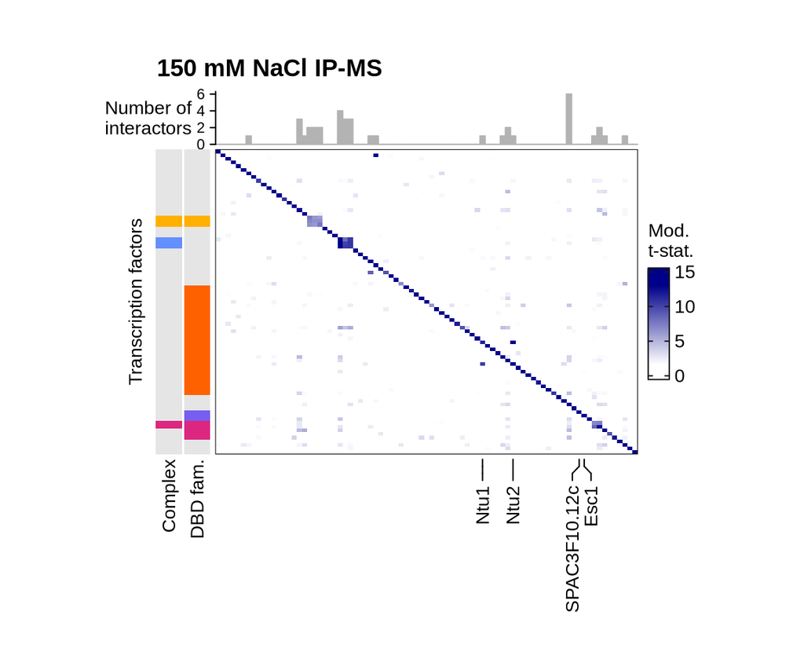

```r
hm1b_loose <- Heatmap(baitdata_150_loose$mat,
                      cluster_rows = FALSE,
                      cluster_columns = FALSE,
                      col = makeHeatmapCol(stringency = "low"),
                      border = TRUE,
                      border_gp = gpar(lwd = 0.5),
                      name = "Mod.\nt-stat.",
                      na_col = binary_heatmap_colors["FALSE"],
                      column_title = paste(c("150 mM NaCl IP-MS", rep(" ", 45)), collapse = ""),
                      row_title = "Transcription factors",
                      column_title_gp = gpar(fontsize = fl + 3, fontface = "bold"),
                      row_title_gp = gpar(fontsize = fl),
                      column_names_gp = gpar(fontsize = fs),
                      row_names_gp = gpar(fontsize = fs),
                      show_row_names = FALSE, show_column_names = FALSE,
                      use_raster = FALSE, show_heatmap_legend = TRUE,
                      left_annotation = makeComplexAndDBDAnnotation(
                          baitdata_150_loose$mat,
                          complexes[c("MBF transcription complex",
                                      "CCAAT-binding factor complex",
                                      "Atf1-Pcr1")],
                          dbd = dbd,
                          idmap = idmap),
                      top_annotation = makeTFIntAnnotation(baitdata_150_loose),
                      bottom_annotation = makeColLabels(baitdata_150_loose$mat,
                                                  c("Ntu1_plate", "Ntu2_plate",
                                                    "Esc1_tube", "SPAC3F10.12c_plate"), fl),
                      width = unit(w_ipmsHm, "mm") / 1.05, # heatmap body width
                      heatmap_height = unit(h_ipmsHm / 1.7, "mm"),
                      heatmap_legend_param = list(title_gp = gpar(fontsize = fl),
                                                  border = "gray10",
                                                  border_gp = gpar(lwd = 0.5)))

hm_150_0.05_bait <- grid.grabExpr(
    hm1b <- draw(hm1b_loose, merge_legend = TRUE,
                 heatmap_legend_side = "right",
                 annotation_legend_side = "right"),
    width = w_ipmsHm / 1.05, height = h_ipmsHm / 1.7
)

plot_grid(hm_150_0.05_bait)
```

```r
pie_bait_150_loose <- makePie(baitdata = baitdata_150_loose,
                              title = "150 mM NaCl\nlenient cutoff")
```

```
## [1] "Expected fraction of 'same family' pairs: 0.14837"
```

### SAGA/NuA4 heatmap

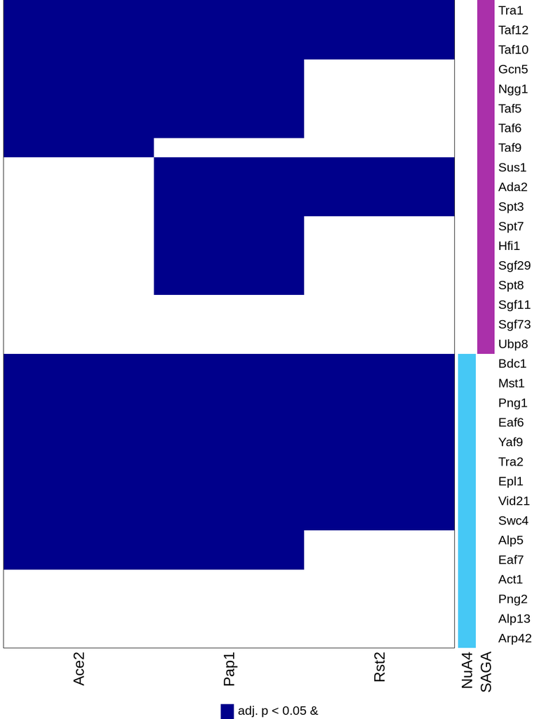

```r
tc150 <- .getTestCols(sce150, adjp_cutoff = 0.05,
                      logfc_cutoff = log2fcThreshold)
keep_proteins <- .capitalize(c(complexes$SAGA$gene_names, complexes$NuA4$gene_names))
keep_exp <- which(.getProteinNameFromComparison(colnames(tc150$adjp)) %in%
                      c("Ace2", "Pap1", "Rst2"))
binary_mat <- tc150$adjp[keep_proteins, keep_exp] < 0.05 &
    tc150$logfc[keep_proteins, keep_exp] > 1
binary_mat[is.na(binary_mat)] <- FALSE
colnames(binary_mat) <- .getProteinNameFromComparison(colnames(binary_mat))
ordr <- order(rownames(binary_mat) %in% .capitalize(complexes$SAGA$gene_names),
              binary_mat[, "Ace2"], binary_mat[, "Pap1"], binary_mat[, "Rst2"],
              decreasing = TRUE)
binary_mat <- binary_mat[ordr, ]

binary_annot <- data.frame(NuA4 = rownames(binary_mat) %in%
                               .capitalize(complexes$NuA4$gene_names),
                           SAGA = rownames(binary_mat) %in%
                               .capitalize(complexes$SAGA$gene_names),
                           row.names = rownames(binary_mat))

mode(binary_mat) <- "character"
ht_opt(HEATMAP_LEGEND_PADDING = unit(0, "mm"))
hm1saga_nua4 <- Heatmap(
    binary_mat,
    cluster_rows = FALSE,
    cluster_columns = FALSE,
    col = binary_heatmap_colors,
    border = TRUE,
    border_gp = gpar(lwd = 0.5),
    name = " ",
    na_col = binary_heatmap_colors["FALSE"],
    column_names_gp = gpar(fontsize = ft),
    row_names_gp = gpar(fontsize = fl),
    show_row_names = TRUE, show_column_names = TRUE,
    use_raster = FALSE, show_heatmap_legend = TRUE,
    right_annotation = rowAnnotation(
        df = binary_annot,
        col = list(SAGA = c(`TRUE` = complex_colors[["SAGA"]],
                            `FALSE` = binary_heatmap_colors[["FALSE"]]),
                   NuA4 = c(`TRUE` = complex_colors[["NuA4"]],
                            `FALSE` = binary_heatmap_colors[["FALSE"]])),
        show_legend = FALSE),
    heatmap_height = unit(1.125 * h_ipmsHm, "mm"), # whole heatmap height
    column_title_gp = gpar(fontsize = ft),
    heatmap_legend_param = list(title_gp = gpar(fontsize = ft),
                                at = c("FALSE", "TRUE"),
                                labels = c("", "adj. p < 0.05 &\nlog2FC > 1"),
                                legend_gap = unit(0, "mm"))
)

hm_150_saga_nua4 <- grid.grabExpr(
    hm1sn <- draw(hm1saga_nua4, merge_legend = TRUE,
                  heatmap_legend_side = "bottom",
                  annotation_legend_side = "right",
                  align_heatmap_legend = "global_center",
                  padding = unit(c(3, 1, 1, 1), "mm")),
    width = w_ipmsHm, height = 1.125 * h_ipmsHm
)

plot_grid(hm_150_saga_nua4)
```

```r
ht_opt(RESET = TRUE)
```

### RNA / DNA binding proteins

```r
rnabinding <- read.delim(params$rnabinders)
keep <- rownames(hmdata_150$tstat) %in% c(rnabinding$PomBaseID, .capitalize(rnabinding$Gene_name))
sum(keep)
```

```
## [1] 29
```

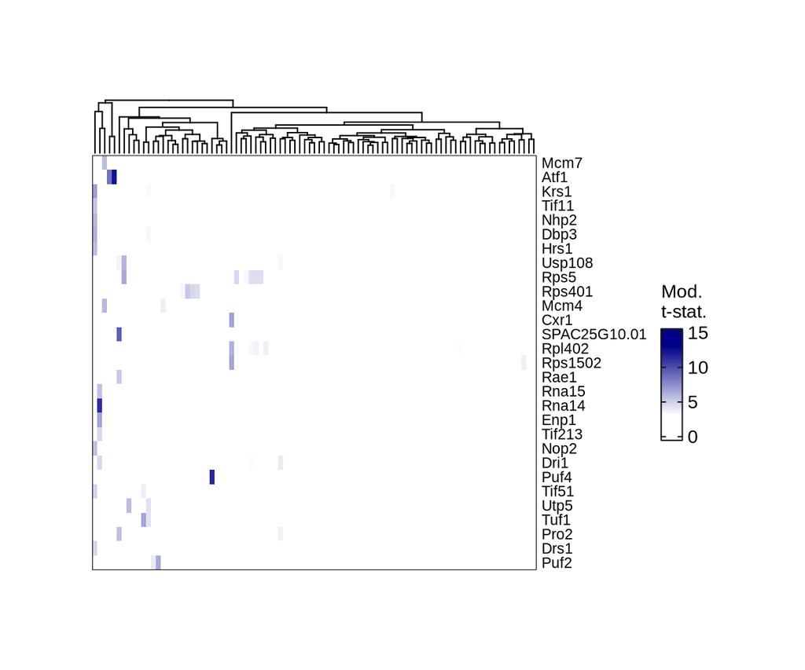

```r
hm1rna <- Heatmap(hmdata_150$tstat[keep, ],
                  cluster_rows = FALSE,
                  cluster_columns = TRUE,
                  col = makeHeatmapCol(stringency = "high"),
                  border = TRUE,
                  border_gp = gpar(lwd = 0.5),
                  name = "Mod.\nt-stat.",
                  na_col = binary_heatmap_colors["FALSE"],
                  column_names_gp = gpar(fontsize = fs),
                  row_names_gp = gpar(fontsize = fs),
                  show_row_names = TRUE, show_column_names = FALSE,
                  use_raster = FALSE, show_heatmap_legend = TRUE,
                  width = unit(w_ipmsHm, "mm"), # heatmap body width
                  heatmap_height = unit(h_ipmsHm/2, "mm"), # whole heatmap height
                  heatmap_legend_param = list(title_gp = gpar(fontsize = fl),
                                border = "gray10",
                                border_gp = gpar(lwd = 0.5)))

set.seed(42L)
hm_150_rna <- grid.grabExpr(
    hm1b <- draw(hm1rna, merge_legend = TRUE,
                heatmap_legend_side = "right",
                annotation_legend_side = "right"),
    width = w_ipmsHm, height = h_ipmsHm/2
)

plot_grid(hm_150_rna)
```

```r
dnabinding <- read.delim(params$dnabinders)
keep <- rownames(hmdata_150$tstat) %in% c(dnabinding$PomBaseID, .capitalize(dnabinding$Gene_name))
sum(keep)
```

```
## [1] 127
```

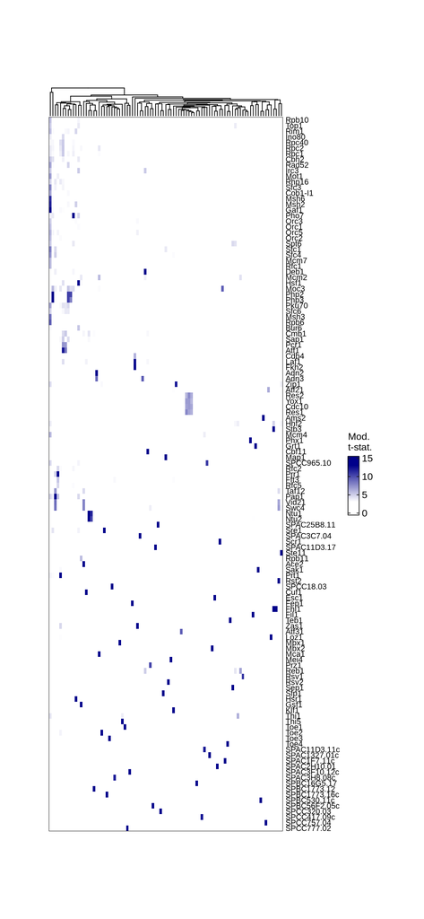

```r
hm1dna <- Heatmap(hmdata_150$tstat[keep, ],
                  cluster_rows = FALSE,
                  cluster_columns = TRUE,
                  col = makeHeatmapCol(stringency = "high"),
                  border = TRUE,
                  border_gp = gpar(lwd = 0.5),
                  name = "Mod.\nt-stat.",
                  na_col = binary_heatmap_colors["FALSE"],
                  column_names_gp = gpar(fontsize = fs),
                  row_names_gp = gpar(fontsize = fs),
                  show_row_names = TRUE, show_column_names = FALSE,
                  use_raster = FALSE, show_heatmap_legend = TRUE,
                  width = unit(w_ipmsHm, "mm"), # heatmap body width
                  heatmap_height = unit(1.5 * h_ipmsHm, "mm"), # whole heatmap height
                  heatmap_legend_param = list(title_gp = gpar(fontsize = fl),
                                border = "gray10",
                                border_gp = gpar(lwd = 0.5)))

set.seed(42L)
hm_150_dna <- grid.grabExpr(
    hm1b2 <- draw(hm1dna, merge_legend = TRUE,
                  heatmap_legend_side = "right",
                  annotation_legend_side = "right"),
    width = w_ipmsHm, height = 1.5 * h_ipmsHm
)
plot_grid(hm_150_dna)
```

## Summary heatmaps using results from the statistical tests (500 mM NaCl)

### Bait-vs-bait heatmap

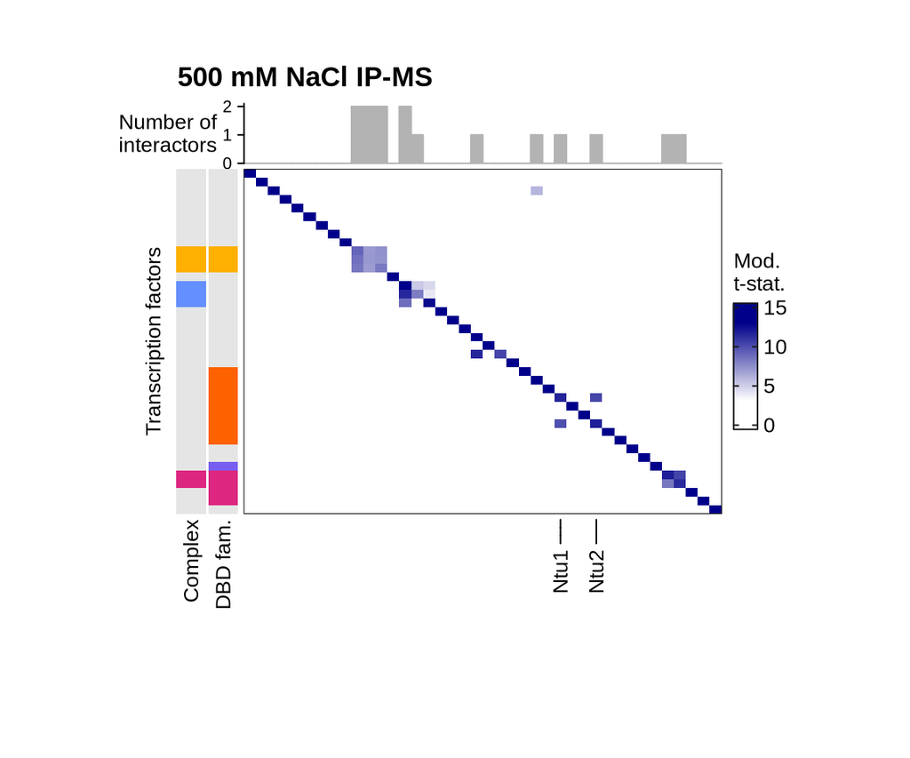

```r
hm1b2 <- Heatmap(baitdata_500$mat,
                 cluster_rows = FALSE,
                 cluster_columns = FALSE,
                 col = makeHeatmapCol(stringency = "high"),
                 border = TRUE,
                 border_gp = gpar(lwd = 0.5),
                 name = "Mod.\nt-stat.",
                 na_col = binary_heatmap_colors["FALSE"],
                 column_title = paste(c("500 mM NaCl IP-MS", rep(" ", 45)), collapse = ""),
                 row_title = "Transcription factors",
                 column_title_gp = gpar(fontsize = fl + 3, fontface = "bold"),
                 row_title_gp = gpar(fontsize = fl),
                 column_names_gp = gpar(fontsize = fs),
                 row_names_gp = gpar(fontsize = fs),
                 show_row_names = FALSE, show_column_names = FALSE,
                 use_raster = FALSE, show_heatmap_legend = TRUE,
                 left_annotation = makeComplexAndDBDAnnotation(
                     baitdata_500$mat,
                     complexes[c("MBF transcription complex",
                                 "CCAAT-binding factor complex", "Atf1-Pcr1")],
                     dbd = dbd, idmap = idmap),
                 top_annotation = makeTFIntAnnotation(baitdata_500),
                 bottom_annotation = makeColLabels(baitdata_500$mat,
                                                  c("Ntu1_plate", "Ntu2_plate",
                                                    "Esc1_plate", "SPAC3F10.12c_plate"), fl),
                 width = unit(w_ipmsHm, "mm") / 1.05, # heatmap body width
                 heatmap_height = unit(h_ipmsHm / 1.7, "mm"), # whole heatmap height
                 heatmap_legend_param = list(title_gp = gpar(fontsize = fl),
                                            border = "gray10",
                                            border_gp = gpar(lwd = 0.5)))

hm_500_bait <- grid.grabExpr(
    hm1b2 <- draw(hm1b2, merge_legend = TRUE,
                  heatmap_legend_side = "right",
                  annotation_legend_side = "right"),
    width = w_ipmsHm / 1.05, height = h_ipmsHm / 1.7
)

plot_grid(hm_500_bait)
```

```r
pie_bait_500 <- makePie(baitdata = baitdata_500,
                        title = "500 mM NaCl\nstrict cutoff")
```

```
## [1] "Expected fraction of 'same family' pairs: 0.06795"
```

```r
pie_bait_500_loose <- makePie(baitdata = baitdata_500_loose,
                              title = "500 mM NaCl\nlenient cutoff")
```

```
## [1] "Expected fraction of 'same family' pairs: 0.06795"
```

## Pie charts for bait-vs-bait interactions (within/between DBD families)

The pie charts below display the number of observed within- and between-DBD family interactions under different salt conditions and using different thresholds for identifying interactions. The black arc indicate the  
fraction of within-DBD family interactions expected by chance.

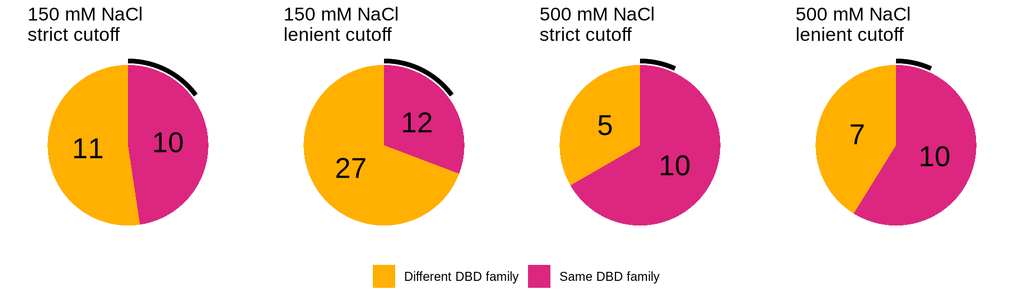

```r
cowplot::plot_grid(
    cowplot::plot_grid(pie_bait_150 + theme(legend.position = "none"),
                       pie_bait_150_loose + theme(legend.position = "none"),
                       pie_bait_500 + theme(legend.position = "none"),
                       pie_bait_500_loose + theme(legend.position = "none"), nrow = 1),
    get_legend(pie_bait_150 + theme(legend.position = "bottom")),
    ncol = 1, rel_heights = c(1, 0.25)
)
```

## Compare t-statistics from low-salt and high-salt conditions

The figures below show scatter plots of moderated t-statistics for selected bait pull-downs compared to their complements, in the high-salt vs low-salt conditions.

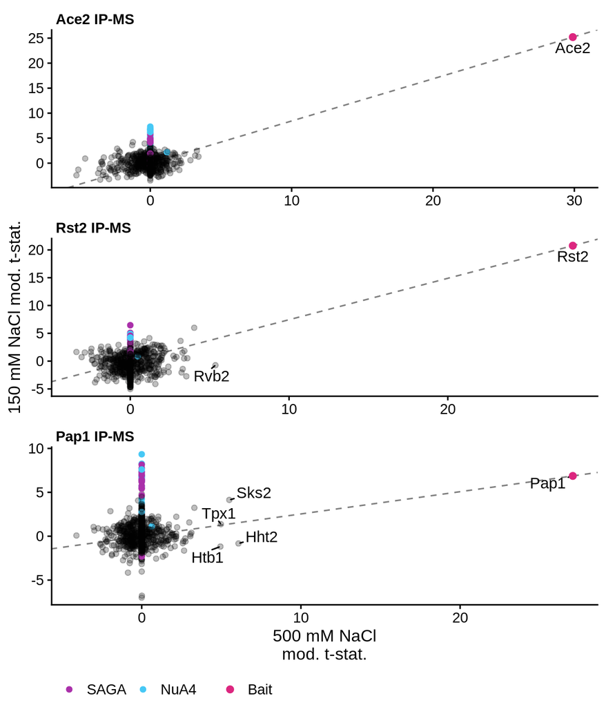

```r
## Extract results from statistical tests
rdlow <- rowData(sce150)
rdhigh <- rowData(sce500)

## Get t-statistics
contrasts_to_compare <- grep("\\.t$", colnames(rdhigh), value = TRUE)
contrasts_low <- gsub("_compl", "_highsaltcompl",
                      gsub("_500_", "_150_", contrasts_to_compare))
idx <- which(!contrasts_low %in% colnames(rdlow))
contrasts_low[idx] <- gsub("_plate", "_tube", contrasts_low[idx])
stopifnot(all(contrasts_low %in% colnames(rdlow)))

## t-statistics, logFCs and adjusted p-values, low salt
low <- as.data.frame(rdlow[, c("einprotId", contrasts_low)]) |>
    tidyr::pivot_longer(names_to = "contrast_low", values_to = "tstat_low", -einprotId) |>
    dplyr::mutate(contrast_low = sub("\\.t$", "", contrast_low)) |>
    dplyr::left_join(
        as.data.frame(rdlow[, c("einprotId", sub("\\.t$", ".adj.P.Val",
                                                 contrasts_low))]) |>
            tidyr::pivot_longer(names_to = "contrast_low",
                                values_to = "adjp_low", -einprotId) |>
            dplyr::mutate(contrast_low = sub("\\.adj.P.Val$", "", contrast_low))) |>
    dplyr::left_join(
        as.data.frame(rdlow[, c("einprotId", sub("\\.t$", ".logFC",
                                                 contrasts_low))]) |>
            tidyr::pivot_longer(names_to = "contrast_low",
                                values_to = "logfc_low", -einprotId) |>
            dplyr::mutate(contrast_low = sub("\\.logFC$", "", contrast_low)))

## t-statistics, logFCs and adjusted p-values, high salt
high <- as.data.frame(rdhigh[, c("einprotId", contrasts_to_compare)]) |>
    tidyr::pivot_longer(names_to = "contrast_high",
                        values_to = "tstat_high", -einprotId) |>
    dplyr::mutate(contrast_high = sub("\\.t$", "", contrast_high)) |>
    dplyr::left_join(
        as.data.frame(rdhigh[, c("einprotId", sub("\\.t$", ".adj.P.Val",
                                                  contrasts_to_compare))]) |>
            tidyr::pivot_longer(names_to = "contrast_high",
                                values_to = "adjp_high", -einprotId) |>
            dplyr::mutate(contrast_high = sub("\\.adj.P.Val$", "",
                                              contrast_high))) |>
    dplyr::left_join(
        as.data.frame(rdhigh[, c("einprotId", sub("\\.t$", ".logFC",
                                                  contrasts_to_compare))]) |>
            tidyr::pivot_longer(names_to = "contrast_high",
                                values_to = "logfc_high", -einprotId) |>
            dplyr::mutate(contrast_high = sub("\\.logFC$", "",
                                              contrast_high))) |>
    dplyr::mutate(contrast_low = sub("\\.t$", "",
                                     contrasts_low[match(paste0(contrast_high, ".t"),
                                                         contrasts_to_compare)]))

## Merge data.frames
lowhigh <- low |> dplyr::full_join(high) |>
    dplyr::mutate(tstat_low = replace(tstat_low, is.na(tstat_low), 0),
                  tstat_high = replace(tstat_high, is.na(tstat_high), 0),
                  logfc_low = replace(logfc_low, is.na(logfc_low), 0),
                  logfc_high = replace(logfc_high, is.na(logfc_high), 0),
                  adjp_low = replace(adjp_low, is.na(adjp_low), 1),
                  adjp_high = replace(adjp_high, is.na(adjp_high), 1)) |>
    dplyr::mutate(bait = .getProteinNameFromComparison(contrast_low)) |>
    dplyr::mutate(splitvar = .getProteinNameFromComparison(contrast_low))

## Add dal2
rddal2 <- rowData(scedal2)
contrasts_low_dal2 <- c("Dal2_150_plate_vs_Untagged_150_plate.t")
low_dal2 <- as.data.frame(rddal2[, c("einprotId", contrasts_low_dal2)]) |>
    tidyr::pivot_longer(names_to = "contrast_low",
                        values_to = "tstat_low", -einprotId) |>
    dplyr::mutate(contrast_low = sub("\\.t$", "", contrast_low)) |>
    dplyr::left_join(
        as.data.frame(rddal2[, c("einprotId", sub("\\.t$", ".adj.P.Val",
                                                  contrasts_low_dal2))]) |>
            tidyr::pivot_longer(names_to = "contrast_low",
                                values_to = "adjp_low", -einprotId) |>
            dplyr::mutate(contrast_low = sub("\\.adj.P.Val$", "", contrast_low))) |>
    dplyr::left_join(
        as.data.frame(rddal2[, c("einprotId", sub("\\.t$", ".logFC",
                                                  contrasts_low_dal2))]) |>
            tidyr::pivot_longer(names_to = "contrast_low",
                                values_to = "logfc_low", -einprotId) |>
            dplyr::mutate(contrast_low = sub("\\.logFC$", "", contrast_low)))

contrasts_high_dal2 <- c("Dal2_500_plate_vs_Untagged_500_plate.t")
high_dal2 <- as.data.frame(rddal2[, c("einprotId", contrasts_high_dal2)]) |>
    tidyr::pivot_longer(names_to = "contrast_high",
                        values_to = "tstat_high", -einprotId) |>
    dplyr::mutate(contrast_high = sub("\\.t$", "", contrast_high)) |>
    dplyr::left_join(
        as.data.frame(rddal2[, c("einprotId", sub("\\.t$", ".adj.P.Val",
                                                  contrasts_high_dal2))]) |>
            tidyr::pivot_longer(names_to = "contrast_high",
                                values_to = "adjp_high", -einprotId) |>
            dplyr::mutate(contrast_high = sub("\\.adj.P.Val$", "", contrast_high))) |>
    dplyr::left_join(
        as.data.frame(rddal2[, c("einprotId", sub("\\.t$", ".logFC",
                                                  contrasts_high_dal2))]) |>
            tidyr::pivot_longer(names_to = "contrast_high",
                                values_to = "logfc_high", -einprotId) |>
            dplyr::mutate(contrast_high = sub("\\.logFC$", "", contrast_high)))

lowhigh_dal2 <- low_dal2 |> dplyr::full_join(high_dal2) |>
    dplyr::mutate(tstat_low = replace(tstat_low, is.na(tstat_low), 0),
                  tstat_high = replace(tstat_high, is.na(tstat_high), 0),
                  logfc_low = replace(logfc_low, is.na(logfc_low), 0),
                  logfc_high = replace(logfc_high, is.na(logfc_high), 0),
                  adjp_low = replace(adjp_low, is.na(adjp_low), 1),
                  adjp_high = replace(adjp_high, is.na(adjp_high), 1)) |>
    dplyr::mutate(bait = .getProteinNameFromComparison(sub("SPB4775_", "",
                                                           contrast_low))) |>
    dplyr::mutate(splitvar = .getProteinNameFromComparison(sub("SPB4775_", "",
                                                               contrast_low)))

lowhigh <- lowhigh |>
    dplyr::bind_rows(lowhigh_dal2)

## Subset 1
adjp150vs500 <- 1e-3
logfc150vs500 <- 1

lowhighsub1 <- lowhigh |>
    dplyr::filter(splitvar %in% c("Ace2", "Rst2", "Pap1")) |>
    dplyr::mutate(splitvar = factor(splitvar, levels = c("Ace2", "Rst2", "Pap1"))) |>
    dplyr::mutate(significant = (adjp_high < adjp150vs500 & logfc_high > logfc150vs500)) |>
    dplyr::mutate(complex = ifelse(einprotId %in% .capitalize(complexes$NuA4$gene_names),
                                   "NuA4", ifelse(einprotId %in% .capitalize(complexes$SAGA$gene_names),
                                                  "SAGA", NA_character_)))

## Subset 2
lowhighsub2 <- lowhigh |>
    dplyr::filter(splitvar %in% c("Atf1", "Pcr1", "Moc3",
                                  "Dal2", "Ntu1", "Ntu2")) |>
    dplyr::mutate(splitvar = factor(splitvar, levels = c("Ntu1", "Ntu2",
                                                         "Atf1", "Pcr1",
                                                         "Moc3", "Dal2"))) |>
    dplyr::mutate(significant = (adjp_high < adjp150vs500 & logfc_high > logfc150vs500))

(gg_retain1 <- ggplot(lowhighsub1,
                      aes(x = tstat_high, y = tstat_low)) +
        geom_abline(data = lowhighsub1 |>
                        dplyr::filter(einprotId == bait),
                    aes(slope = tstat_low / tstat_high, intercept = 0),
                    linetype = "dashed", color = "grey50") +
        geom_text_repel(data = lowhighsub1 |>
                                dplyr::mutate(
                                    einprotId = ifelse(significant, einprotId, "")),
                        aes(label = einprotId), min.segment.length = 0,
                        max.overlaps = Inf) +
        geom_point(aes(alpha = !is.na(complex), color = complex),
                   show.legend = c(alpha = FALSE, color = TRUE)) +
        scale_color_manual(values = complex_colors, na.value = "black",
                           breaks = c("SAGA", "NuA4")) +
        scale_alpha_manual(values = c(`TRUE` = 1, `FALSE` = 0.25)) +
        geom_point(data = lowhighsub1 |> dplyr::filter(einprotId == bait) |>
                       dplyr::mutate(type = "Bait"),
                   mapping = aes(fill = type), color = main_colors[3],
                   shape = 21, alpha = 1, size = 2) +
        scale_fill_manual(values = c(Bait = main_colors[3])) +
        facet_wrap(~ splitvar, scales = "free", ncol = 1,
                   labeller = labeller(splitvar = structure(
                       paste0(unique(lowhighsub1$splitvar), " IP-MS"),
                       names = as.character(unique(lowhighsub1$splitvar))))) +
        labs(x = "500 mM NaCl\nmod. t-stat.", y = "150 mM NaCl mod. t-stat.") +
        theme_cowplot(ft) +
        theme(legend.position = "bottom",
              strip.background = element_rect(fill = NA, colour = NA),
              strip.text = element_text(hjust = 0, face = "bold")) +
        guides(color = guide_legend(nrow = 1, byrow = TRUE, title = ""),
               fill = guide_legend(nrow = 1, byrow = TRUE, title = "")))
```

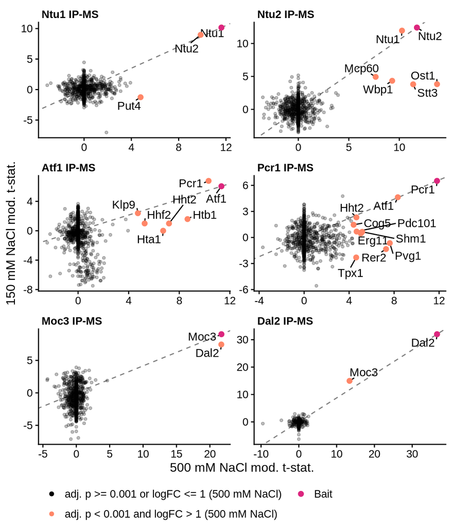

```r
(gg_retain2 <- ggplot(lowhighsub2,
                      aes(x = tstat_high, y = tstat_low)) +
        geom_abline(data = lowhighsub2 |>
                        dplyr::filter(einprotId == bait),
                    aes(slope = tstat_low / tstat_high, intercept = 0),
                    linetype = "dashed", color = "grey50") +
        geom_text_repel(data = lowhighsub2 |>
                            dplyr::mutate(einprotId = ifelse(significant, einprotId, "")),
                        aes(label = einprotId), min.segment.length = 0,
                        max.overlaps = Inf) +
        geom_point(aes(alpha = significant, color = significant, size = significant),
                   show.legend = c(alpha = FALSE, color = TRUE, size = FALSE)) +
        scale_color_manual(
            values = c(`TRUE` = lighten(main_colors[4], 0.2), `FALSE` = "black"),
            labels = c(`TRUE` = paste0("adj. p < ", adjp150vs500,
                                       " and logFC > ", logfc150vs500, " (500 mM NaCl)"),
                       `FALSE` = paste0("adj. p >= ", adjp150vs500,
                                        " or logFC <= ", logfc150vs500, " (500 mM NaCl)"))) +
        scale_size_manual(values = c(`TRUE` = 2, `FALSE` = 1)) +
        scale_alpha_manual(values = c(`TRUE` = 1, `FALSE` = 0.25)) +
        geom_point(data = lowhighsub2 |>
                       dplyr::filter(einprotId == bait) |>
                       dplyr::mutate(type = "Bait"),
                   mapping = aes(fill = type), color = main_colors[3],
                   shape = 21, alpha = 1, size = 2) +
        scale_fill_manual(values = c(Bait = main_colors[3])) +
        facet_wrap(~ splitvar, scales = "free", ncol = 2,
                   labeller = labeller(splitvar = structure(
                       paste0(unique(lowhighsub2$splitvar), " IP-MS"),
                       names = as.character(unique(lowhighsub2$splitvar))))) +
        labs(x = "500 mM NaCl mod. t-stat.", y = "150 mM NaCl mod. t-stat.") +
        theme_cowplot(ft) +
        theme(legend.position = "bottom",
              strip.background = element_rect(fill = NA, colour = NA),
              strip.text = element_text(hjust = 0, face = "bold")) +
        guides(color = guide_legend(nrow = 2, byrow = TRUE, title = ""),
               fill = guide_legend(nrow = 1, byrow = TRUE, title = "")))
```

## Supplementary plot - tube vs plate t-statistics for Atf1 pull-down

The low-salt experiments were done using two different protocols (`tube` or `plate`). The `Atf1` pull-down was performed with both protocols, and the figure below compares the moderated t-statistics (each obtained by comparing to the complement consisting of all non-`Atf1` pull-down samples obtained with the same protocol).

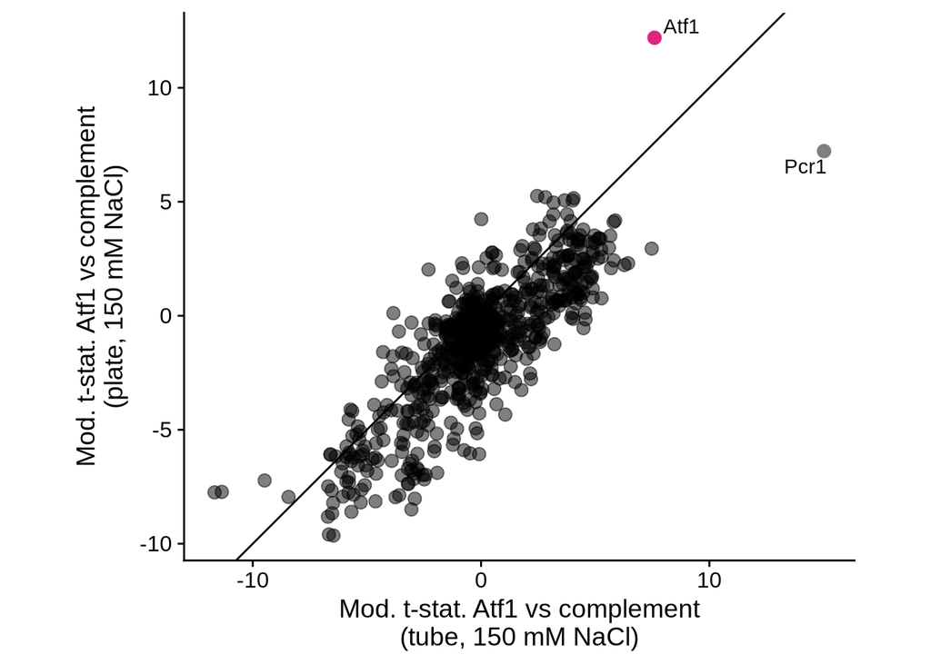

```r
df <- as.data.frame(rowData(sce150)) |>
    dplyr::select(einprotId, Atf1_150_tube_vs_compl_Atf1_150_tube.t,
                  Atf1_150_plate_vs_compl_Atf1_150_plate.t) |>
    dplyr::mutate(col = ifelse(einprotId == "Atf1", "bait",
                               ifelse(einprotId == "Pcr1", "Pcr1", "other")))
(ggatf1 <- ggplot(df, aes(x = Atf1_150_tube_vs_compl_Atf1_150_tube.t,
                         y = Atf1_150_plate_vs_compl_Atf1_150_plate.t)) +
    geom_abline(slope = 1, intercept = 0) +
    geom_point(size = 3, aes(color = col, alpha = col)) +
    scale_color_manual(values = c(bait = main_colors[3], pcr1 = main_colors[4],
                                  other = "black")) +
    scale_alpha_manual(values = c(bait = 1, pcr1 = 1, other = 0.5)) +
    geom_text_repel(data = df |> filter(einprotId %in% c("Atf1", "Pcr1")),
                    aes(label = einprotId)) +
    labs(x = "Mod. t-stat. Atf1 vs complement\n(tube, 150 mM NaCl)",
         y = "Mod. t-stat. Atf1 vs complement\n(plate, 150 mM NaCl)") +
    coord_fixed() +
    theme_cowplot() +
    theme(legend.position = "none"))
```

## Put together

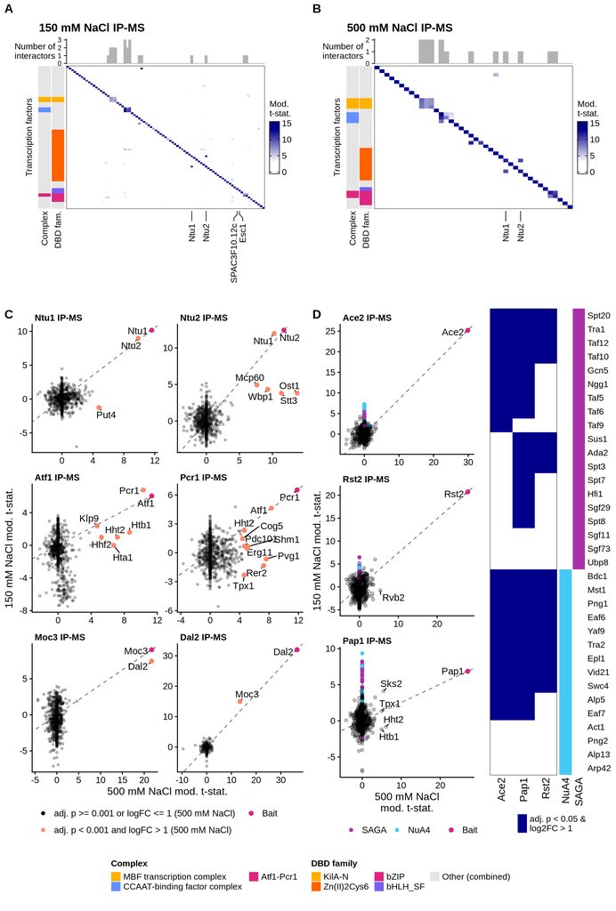

```r
cowplot::plot_grid(
    cowplot::plot_grid(
        hm_150_bait, hm_500_bait,
        gg_retain2,
        plot_grid(gg_retain1, NULL, hm_150_saga_nua4, nrow = 1, rel_widths = c(1, 0.05, 0.75)),
        rel_heights = c(4, 7),
        labels = c("A", "B", "C", "D")
    ),
    cowplot::plot_grid(
        NULL,
        legend_bait_1,
        legend_bait_2,
        NULL,
        nrow = 1,
        rel_widths = c(1, 2, 2, 1)
    ),
    nrow = 2,
    rel_heights = c(12, 1)
)
```